# U.S. Census surveys

Dataset of the Week (Week 2)

# Background

The United States Census Bureau conducts dozens of surveys and data collection programs. You can find a list of them here: https://www.census.gov/programs-surveys/surveys-programs.html.

You can read the Census Bureau’s description of its mission, authority, and activities here: https://www.census.gov/about/what.html.

They describe their mission as “to serve as the nation’s leading provider of quality data about its people and economy.”

This page focuses on two of the largest efforts of the United States Census bureau: The Decennial Census of Population and Housing and the American Community Survey.

# Decennial Census

Article 1, Section 2 of the United States Constitution requires that Members of the House of Representatives be apportioned among states proportionate to state populations,[^1] and requires that a census be conducted every ten years to determine populations for the purposes of designating legislative districts.

The Decennial Census is intended to enumerate every person living in the United States, regardless of citizenship or housing status. Data are collected about people and households, where a household is defined as all people living in a single housing unit. A housing unit could be any structure, including a vehicle or a tent. People who do not live in housing units are classified as living in group quarters[^2], including:

- Institutional
  - Correctional facilities
  - Nursing homes
  - Hospitals
- Non-institutional
  - College dormitories
  - Military barracks
  - Group homes
  - Missions/shelters

Data collected in the decennial census include the following information about each household member:

- Race
- Ethnicity (Hispanic origin)
- Sex (classified as male or female),
- Relationship to the householder.

The “householder” can be any adult. If one person owns the housing unit or pays rent for the entire household, that person is classified as the householder.

The tenure of the housing unit is also collected: whether the home is owned without a mortgage, owned with a mortgage, rented, or occupied without ownership or payment of rent.

Data are collected by mail-in surveys, and census workers visit housing units in person to collect data from households with no mailing address or who did not return a survey. You can see a sample of the 2020 census form [here](https://www2.census.gov/programs-surveys/decennial/2020/technical-documentation/questionnaires-and-instructions/questionnaires/2020-informational-questionnaire-english_DI-Q1.pdf).

# American Community Survey

Between 1970 and 2000, a random sample of respondents to the Decennial Census received a “long-form census” that collected more data than the standard census census forms. In 2005, the long-form census forms were discontinued and replaced by the American Community Survey.

The Census Bureau has collected the American Community Survey (ACS) since 2005 from a randomly-selected sample of United States residents each year, over a twelve-month period. The ACS collects data on a much broader set of topics than the Decennial census does, including:

- Residential mobility (moves within the past year)
- Travel to work
  - Means of transportation
  - Travel time
  - Time leaving home and arriving at work
- Income
- Education level
- School enrollment
- Occupation
- Employment status

Estimated characteristics for the entire population are calculated based on the responses from the sample of the population that took the survey. Because these are estimates from a sample rather than counts of the full population, there is a margin of error associated with them. The margin of error the census reports is for a 90-percent confidence level.

Data are available as one-year estimates (all responses collected in a given year) and as five-year estimates (all responses collected over a five year period). Five-year estimates have larger sample sizes, resulting in smaller margins of error.

Here’s a little video that explains more about margins of error:

https://www.census.gov/data/academy/data-gems/2024/what-is-the-margin-of-error.html.

# Data tables

The Census Bureau publishes data from the Decennial Census and the American Community Survey in data tables aggregated by geographic areas (the boundaries of which are available from [Census TIGER files](https://c-voulgaris.github.io/VIS-2128/week1/dataset-tiger.html#geographic-areas))

The unit of analysis in a data table will be a geographic area, and each table will include a set of variables. Variables might be the number of individuals or households in each of several categories. In this case, one of the variables will generally be the total across categories, and other variables might be totals within subcategories. For example, here is Table H003 from the 2010 Decennial Census for Congressional Districts in Mississippi. Table H003 is about the occupancy status of housing units. It includes three variables:

- The total number of housing units (H003001)
- The number of occupied housing units (H003002), and
- The number of vacant units (H003003).

| GEOID | NAME | H003001: Total housing units | H003002: Total occupied housing units | H003003: Total vacant housing units |
| --- | --- | --- | --- | --- |
| 2801 | Congressional District 1 (111th Congress), Mississippi | 338,959 | 299,632 | 39,327 |
| 2803 | Congressional District 3 (111th Congress), Mississippi | 328,735 | 290,731 | 38,004 |
| 2804 | Congressional District 4 (111th Congress), Mississippi | 331,451 | 284,876 | 46,575 |
| 2802 | Congressional District 2 (111th Congress), Mississippi | 275,574 | 240,529 | 35,045 |

Here is Table B05012 from the 2010 American Community Survey (five-year estimates) for Congressional Districts in Utah. It includes an estimate and a margin of error (for 90-percent confidence) for each of three variables:

- The total population
- The total native-born population
- The total foreign-born population

| GEOID | NAME | B05012_001: Total population (estimate) | B05012_001: Total population (margin of error) | B05012_002: Total native-born population (estimate) | B05012_002: Total native-born population (margin of error) | B05012_003: Total foreign-born population (estimate) | B05012_003: Total foreign-born population (margin of error) |
| --- | --- | --- | --- | --- | --- | --- | --- |
| 4901 | Congressional District 1 (111th Congress), Utah | 870,579 | 1,580 | 801,602 | 2,241 | 68,977 | 2,297 |
| 4902 | Congressional District 2 (111th Congress), Utah | 865,134 | 2,166 | 806,377 | 2,576 | 58,757 | 2,051 |
| 4903 | Congressional District 3 (111th Congress), Utah | 921,523 | 1,611 | 830,974 | 2,702 | 90,549 | 2,149 |

Many data tables (for both the Decennial Census and the American Community Survey) will include cross-categories. For example, Table H019 from the Decennial Census has data on household tenure by the presence of household children.

| GEOID | NAME | H019001: Total occupied housing units | H019002: Total owner-occupied housing units | H019003: Total owner-occupied housing units with children | H019004: Total owner-occupied housing units without children | H019005: Total renter-occupied housing units | H019006: Total renter-occupied housing units with children | H019007: Total renter-occupied housing units without children |
| --- | --- | --- | --- | --- | --- | --- | --- | --- |
| 1501 | Congressional District 1 (111th Congress), Hawaii | 227,263 | 124,468 | 38,054 | 86,414 | 102,795 | 33,547 | 69,248 |
| 1502 | Congressional District 2 (111th Congress), Hawaii | 228,075 | 138,214 | 47,341 | 90,873 | 89,861 | 37,006 | 52,855 |

# Microdata

The Census Bureau also publishes microdata that has the individuals and households rather than geographic areas as the unit of analysis. The most specific geographic data for which microdata are available is the Public Use Microdata Area (PUMA). A PUMA is a set of contiguous census tracts within a single state that have a combined population of at least 100,000 people. Each census tract in the United States is classified into one (and only one) PUMA.

# Data access

Two ways to access data from the Decennial Census or the American Community Survey are through the Census’s online interface and through their API.

## Web interface

You can access census data from https://data.census.gov/.

From the [advanced search page](https://data.census.gov/advanced), you can use several categories of filters.

*Geography* filters can specify the unit of analysis you want (e.g. census tracts or counties) as well as to filter for data within a specific geography (e.g. only census tracts in Middlesex County or only counties within Texas).

*Topic* filters can be useful for finding the table/variable you are interested in.

*Survey* filters will limit your search results to one or more specific surveys, such as the Decennial Census or the American Community Survey.

*Year* filters will limit your search to data from a specific year.

*Code* filters are not relevant to the American Community Survey or the Decennial Census.

## API access

Three functions in the `tidycensus` package will be especially useful. You can find detailed documentation and resources for the `tidycensus` package here: https://walker-data.com/tidycensus/articles/basic-usage.html

The `load_variables` function will allow you to search for the variables that interest you. It takes two required parameters: The year, and the dataset.

For the Decennial Census years before 2020, use `"sf1"`.

The full data from the 2020 Decennial Census haven’t been released yet, but limited data are available in the redistricing data. To see these variables, use `"pl"` as your dataset.

For the American Community Survey, use `"acs1"` for one-year estimates or `"acs5"` for five-year estimates.

If you run the line below in your console, you’ll see this table describing all the available variables from the 2010 Decennial Census. Note that this is searchable.

[figure not shown]

Figure 1: Searching for census variables

```r
load_variables(2010, "sf1") |> View()
```

Once you’ve identified the names of the variables you want, you can use `get_acs` to get data from the American Community Survey or `get_decennial` to get data from the Decennial census.

For either of these functions, you need to specify the year and the geography for which you want data. For some small geographies, you’ll need to specify a state and possibly a county. You’ll also specify the list of variable names you need.

By default, the result will be a table with the name of the variable in one column and the value in another, like this:

```r
CDs_HI_long <- get_decennial(geography = "congressional district",
                        state = "Hawaii",
                        year = 2010,
                        variables = c("H004001",
                                      "H004004"))

CDs_HI_long
```

```
## # A tibble: 4 × 4
##   GEOID NAME                                              variable  value
##   <chr> <chr>                                             <chr>     <dbl>
## 1 1501  Congressional District 1 (111th Congress), Hawaii H004001  227263
## 2 1502  Congressional District 2 (111th Congress), Hawaii H004001  228075
## 3 1501  Congressional District 1 (111th Congress), Hawaii H004004  102795
## 4 1502  Congressional District 2 (111th Congress), Hawaii H004004   89861
```

You can specify that you want each variable in its own column by setting `output = 'wide'`.

```r
CDs_HI_wide <- get_decennial(geography = "congressional district",
                        state = "Hawaii",
                        year = 2010,
                        variables = c("H004001",
                                      "H004004"),
                        output = 'wide')

CDs_HI_wide
```

```
## # A tibble: 2 × 4
##   GEOID NAME                                              H004001 H004004
##   <chr> <chr>                                               <dbl>   <dbl>
## 1 1501  Congressional District 1 (111th Congress), Hawaii  227263  102795
## 2 1502  Congressional District 2 (111th Congress), Hawaii  228075   89861
```

You can also indicate that you want the data as a geospatial dataset that includes the boundaries the the geographic areas by setting `geometry = TRUE`.

```r
counties_DE_geo <- get_decennial(geography = "county",
                        state = "Delaware",
                        year = 2010,
                        variables = c("H004001",
                                      "H004004"),
                        output = 'wide',
                        geometry = TRUE)
```

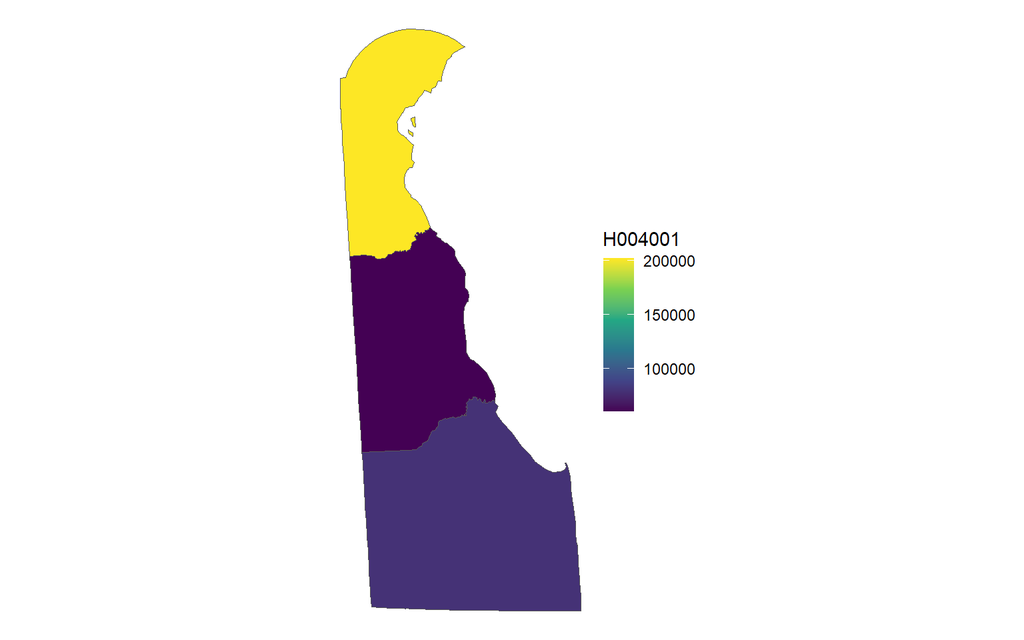

```r
ggplot(counties_DE_geo) +
  geom_sf(aes(fill = H004001)) +
  scale_fill_viridis_c() +
  theme_void()
```

[^1]: The text of Article 1, Section 2 defines the population for purposes of determining the number of Representatives as the number of free persons, excluding indigenous people who were not citizens, plus three-fifths of the population of enslaved persons. In 1868, the 14th Amendment to the Constitution was ratified, requiring that representatives be determined based on the full population of each state, still excluding non-citizen indigenous people. In 1924, Congress passed the Indian Citizenship Act granting United States citizenship to all Native Americans born within the boundaries of the United States, making this special exception irrelevant.
[^2]: https://www.census.gov/topics/income-poverty/poverty/guidance/group-quarters.html
[^3]: https://cenpy-devs.github.io/cenpy/